# Modeling and prediction for movies

## Setup

### Load packages

```r
#Load Packages
library(ggplot2)
library(dplyr)
library(statsr)
library(GGally)
```

### Load data

Make sure your data and R Markdown files are in the same directory. When loaded your data file will be called `movies`. Delete this note when before you submit your work.

```r
#Load Data
load("movies.Rdata")
```

## Part 1: Data

The movies dataset is made up of 651 randomly sampled movies produced and released before 2016 from Rotten Tomatoes and IMBD. Since random sampling was used to collect the data, the results can be generalised to movies produced and released between 1970 and 2016.

However, only correlational statements and conclusions can be made as this is an observational study and the data collection involved no random assignment to perform an experiment.

The data in the dataset comes from Rotten Tomatoes and IMDB, both of which are sites that volunteers contribute to. It’s possible that only people with strong opinions about a movie and movie enthusiasts contribute to the two sites. Hence, the data itself might include convenience and response biases that makes the data different from that of the actual population.

## Part 2: Research question

What aspects of a movie are associated closely with the audience score on Rotten Tomatoes?

We’ll look at the different variables of a movie such as genre, runtime etc. to investigate to what extent they can predict audience_score.

It will be interesting to see what kind of influence different factors have on the audience’s scores.

## Part 3: Exploratory data analysis

### Data Pre-processing

We will not be using all the variables given in the dataset as some of them are not quite relevant for our purposes. We will get rid of the title, studio, director, actor1 - actor5, mpaa_rating, imdb_url and rt_url since these are of no statistical relevance. We will also get rid of the release dates for DVD to simplify the analysis.

```r
#Extract data
moviedata <- movies %>% select(-title, -mpaa_rating, -studio,
                               -thtr_rel_day:-dvd_rel_day, -imdb_num_votes, -director:-rt_url)
```

Let’s now look at a summary of the data.

```r
#Summary of the data
summary(moviedata)
```

```
##         title_type                 genre        runtime
##  Documentary : 55   Drama             :305   Min.   : 39.0
##  Feature Film:591   Comedy            : 87   1st Qu.: 92.0
##  TV Movie    :  5   Action & Adventure: 65   Median :103.0
##                     Mystery & Suspense: 59   Mean   :105.8
##                     Documentary       : 52   3rd Qu.:115.8
##                     Horror            : 23   Max.   :267.0
##                     (Other)           : 60   NA's   :1
##  thtr_rel_year  thtr_rel_month   imdb_rating            critics_rating
##  Min.   :1970   Min.   : 1.00   Min.   :1.900   Certified Fresh:135
##  1st Qu.:1990   1st Qu.: 4.00   1st Qu.:5.900   Fresh          :209
##  Median :2000   Median : 7.00   Median :6.600   Rotten         :307
##  Mean   :1998   Mean   : 6.74   Mean   :6.493
##  3rd Qu.:2007   3rd Qu.:10.00   3rd Qu.:7.300
##  Max.   :2014   Max.   :12.00   Max.   :9.000
##
##  critics_score    audience_rating audience_score  best_pic_nom
##  Min.   :  1.00   Spilled:275     Min.   :11.00   no :629
##  1st Qu.: 33.00   Upright:376     1st Qu.:46.00   yes: 22
##  Median : 61.00                   Median :65.00
##  Mean   : 57.69                   Mean   :62.36
##  3rd Qu.: 83.00                   3rd Qu.:80.00
##  Max.   :100.00                   Max.   :97.00
##
##  best_pic_win best_actor_win best_actress_win best_dir_win top200_box
##  no :644      no :558        no :579          no :608      no :636
##  yes:  7      yes: 93        yes: 72          yes: 43      yes: 15
##
##
##
##
##
```

Looking through the data, we see that runtime has 1 NA value. We will get rid of this observation.

```r
#Get rid of the observations with NA
moviedata <- moviedata %>% na.omit()
```

### Exploration of the data

For our research question we are ultimately interested in predicting the audience reception of a movie. Hence our response variables would be audience_score. Let’s look at a histogram of this variable to get a sense of the distribution shape.

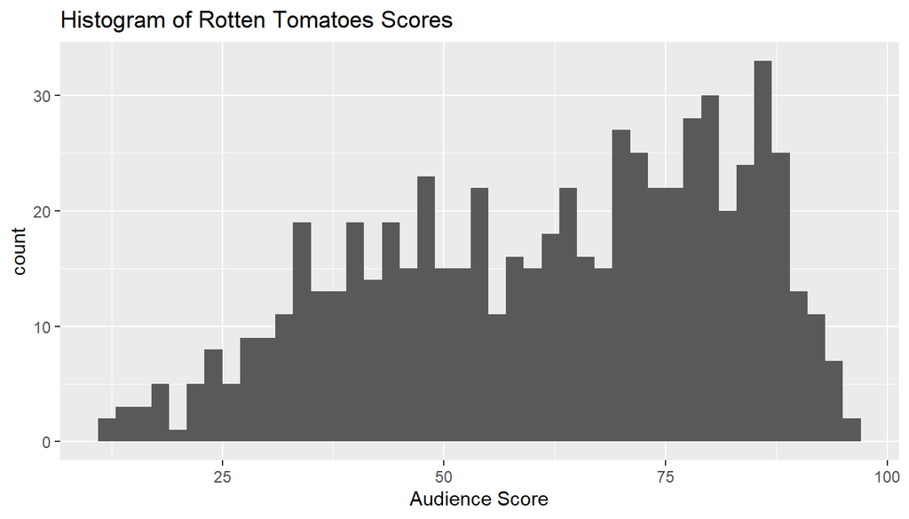

```r
#Histogram of Rotten Tomatoes Audience Scores
ggplot(moviedata, aes(x = audience_score)) + geom_histogram(binwidth = 2) +
  labs(title ="Histogram of Rotten Tomatoes Scores" ,x = "Audience Score")
```

The plot shows left skewness, with the bulk of the responses in the right section of the plot.

Let’s now look at pairwise relationships of some of the numerical variables we want to include in our model later on.

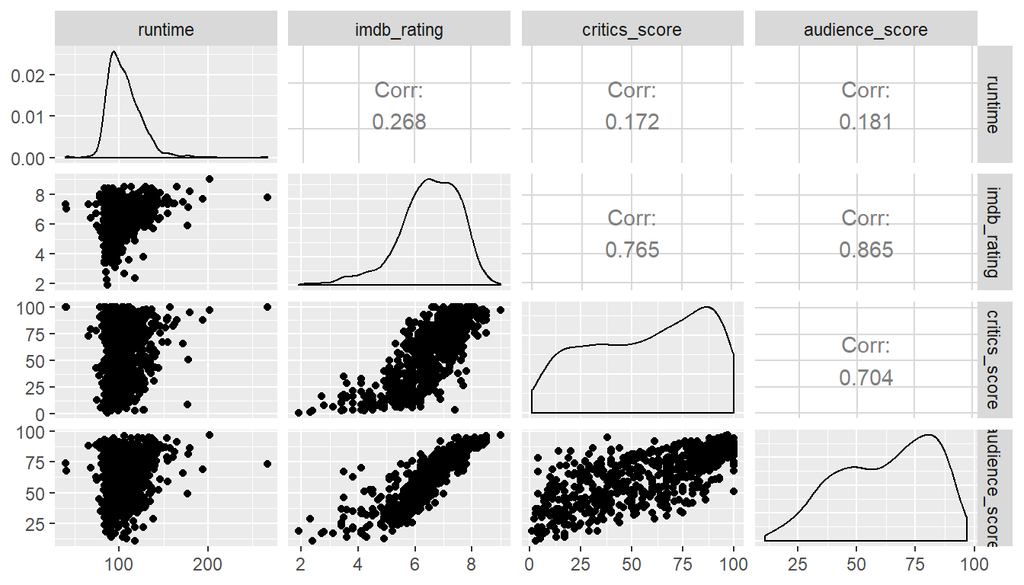

```r
#Pairwise Plots
ggpairs(moviedata, columns = c(3,6,8,10))
```

From the pairwise scatterplots and the calculated correlation coefficients, we see that the correlations between the runtime and other variables are minimal. However, imdb_rating, critics_score and audience_score show stronger correlations with each other.

## Part 4: Modeling

In this section, we will be building a multiple linear regression model with audience_score as the response variable. The full model for audience score will include title type, genre, runtime, release year and month, critics score,imdb rating, best picture nomination and win, best actor/actress/director Oscar wins and top whether the movie made it into the 200 box office list.

We are excluding title, studio, director, actor1 - actor5, mpaa_rating, imdb_url and rt_url since these are of no statistical relevance. We also excluded theatre release day, and DVD release dates since these are not so relevant to our analyses. We will also remove audience_rating since it is just a consolidated version of the audience_score and it doesn’t make sense to predict one when you have the other.

### Model Fit

We’ll be using backward elimination with adjusted R squared as the model selection method since it lets us drop variables one by one until we reach an adequately parsimonious model. We’ll use adjusted R-squared instead of p-value because unlike p-value, adjusted R-squared gives us an idea of the overall model fit and not just for each individual variable. First let’s fit the model for audience_score.

```r
#Fit Full Model
audience <- moviedata %>% select(-audience_rating)
full <- lm(audience_score ~ ., data = audience)
summary(full)
```

```
##
## Call:
## lm(formula = audience_score ~ ., data = audience)
##
## Residuals:
##     Min      1Q  Median      3Q     Max
## -25.821  -5.643   0.284   5.676  49.471
##
## Coefficients:
##                                  Estimate Std. Error t value Pr(>|t|)
## (Intercept)                    153.530795  76.320759   2.012  0.04469 *
## title_typeFeature Film           0.922444   3.614573   0.255  0.79865
## title_typeTV Movie               2.100403   5.702893   0.368  0.71277
## genreAnimation                   9.144993   3.504149   2.610  0.00928 **
## genreArt House & International  -0.114372   2.896952  -0.039  0.96852
## genreComedy                      2.351896   1.623248   1.449  0.14787
## genreDocumentary                 2.951590   3.851704   0.766  0.44378
## genreDrama                       0.511358   1.402501   0.365  0.71553
## genreHorror                     -5.401877   2.383496  -2.266  0.02377 *
## genreMusical & Performing Arts   5.800534   3.319953   1.747  0.08110 .
## genreMystery & Suspense         -5.184403   1.804570  -2.873  0.00421 **
## genreOther                       0.872553   2.778031   0.314  0.75356
## genreScience Fiction & Fantasy  -1.363055   3.481819  -0.391  0.69558
## runtime                         -0.033550   0.023541  -1.425  0.15461
## thtr_rel_year                   -0.090667   0.037737  -2.403  0.01657 *
## thtr_rel_month                  -0.181851   0.112022  -1.623  0.10502
## imdb_rating                     15.043445   0.590060  25.495  < 2e-16 ***
## critics_ratingFresh             -2.837354   1.211384  -2.342  0.01948 *
## critics_ratingRotten            -5.425560   1.937692  -2.800  0.00527 **
## critics_score                   -0.006353   0.035377  -0.180  0.85754
## best_pic_nomyes                  5.149062   2.564670   2.008  0.04511 *
## best_pic_winyes                 -3.098283   4.456411  -0.695  0.48716
## best_actor_winyes               -1.197347   1.155720  -1.036  0.30060
## best_actress_winyes             -2.087127   1.283668  -1.626  0.10447
## best_dir_winyes                 -1.019610   1.683161  -0.606  0.54489
## top200_boxyes                    1.557859   2.652079   0.587  0.55714
## ---
## Signif. codes:  0 '***' 0.001 '**' 0.01 '*' 0.05 '.' 0.1 ' ' 1
##
## Residual standard error: 9.714 on 624 degrees of freedom
## Multiple R-squared:  0.7784, Adjusted R-squared:  0.7695
## F-statistic: 87.68 on 25 and 624 DF,  p-value: < 2.2e-16
```

We see that the adjusted R-squared is 76.95%. We will now perform backward selection using the step function with direction ‘backward’ to check if a more parsimonious model is possible.

```r
#Backward elimination for Rotten Tomatoes audience score
final <- step(full, direction = "backward", trace = 0)
summary(final)
```

```
##
## Call:
## lm(formula = audience_score ~ genre + runtime + thtr_rel_year +
##     thtr_rel_month + imdb_rating + critics_rating + best_pic_nom +
##     best_actress_win, data = audience)
##
## Residuals:
##     Min      1Q  Median      3Q     Max
## -25.617  -5.931   0.234   5.559  49.592
##
## Coefficients:
##                                 Estimate Std. Error t value Pr(>|t|)
## (Intercept)                    148.45395   74.46183   1.994  0.04662 *
## genreAnimation                   8.93984    3.48351   2.566  0.01051 *
## genreArt House & International  -0.01262    2.87025  -0.004  0.99649
## genreComedy                      2.18612    1.60630   1.361  0.17401
## genreDocumentary                 2.04438    2.00333   1.020  0.30789
## genreDrama                       0.40481    1.37637   0.294  0.76877
## genreHorror                     -5.47125    2.36523  -2.313  0.02103 *
## genreMusical & Performing Arts   5.44073    3.09833   1.756  0.07957 .
## genreMystery & Suspense         -5.46059    1.78250  -3.063  0.00228 **
## genreOther                       1.05722    2.74549   0.385  0.70031
## genreScience Fiction & Fantasy  -1.22551    3.46615  -0.354  0.72378
## runtime                         -0.04074    0.02268  -1.796  0.07294 .
## thtr_rel_year                   -0.08736    0.03698  -2.362  0.01847 *
## thtr_rel_month                  -0.18099    0.11118  -1.628  0.10405
## imdb_rating                     14.97672    0.50436  29.695  < 2e-16 ***
## critics_ratingFresh             -2.84176    1.16318  -2.443  0.01483 *
## critics_ratingRotten            -5.16213    1.27373  -4.053 5.69e-05 ***
## best_pic_nomyes                  4.05818    2.30535   1.760  0.07884 .
## best_actress_winyes             -2.17264    1.27304  -1.707  0.08838 .
## ---
## Signif. codes:  0 '***' 0.001 '**' 0.01 '*' 0.05 '.' 0.1 ' ' 1
##
## Residual standard error: 9.681 on 631 degrees of freedom
## Multiple R-squared:  0.7775, Adjusted R-squared:  0.7711
## F-statistic: 122.5 on 18 and 631 DF,  p-value: < 2.2e-16
```

From the output, we see that the regression model with only the genre, runtime, theatre release year and month, imdb rating, critics rating, best pic nomination and best actress winning is a parsimonious model with an adjusted R-squared value of 77.11%.

### Model Diagnostics

**Linear relationships between predictor and response**  
We’ll first check for linear relationships between numerical predictor variables and the response variable audience_score by plotting residuals against each predictor.

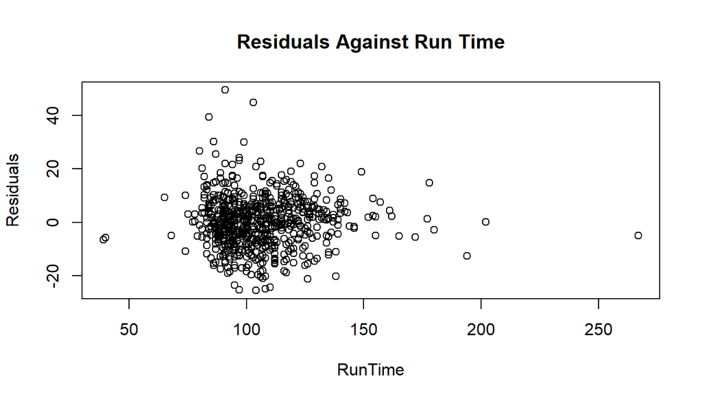

```r
#Residuals against Run Time
plot(final$residuals ~ audience$runtime, main = "Residuals Against Run Time", ylab = "Residuals",
     xlab = "RunTime")
```

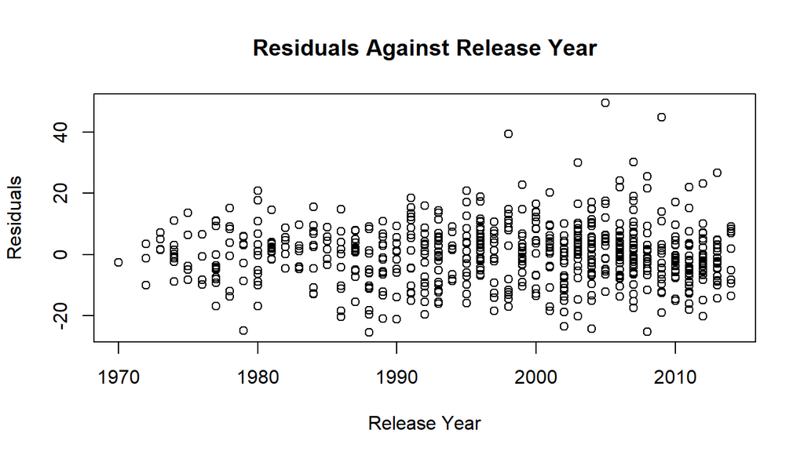

```r
#Residuals against Release Year
plot(final$residuals ~ audience$thtr_rel_year, main = "Residuals Against Release Year",
     ylab = "Residuals", xlab = "Release Year")
```

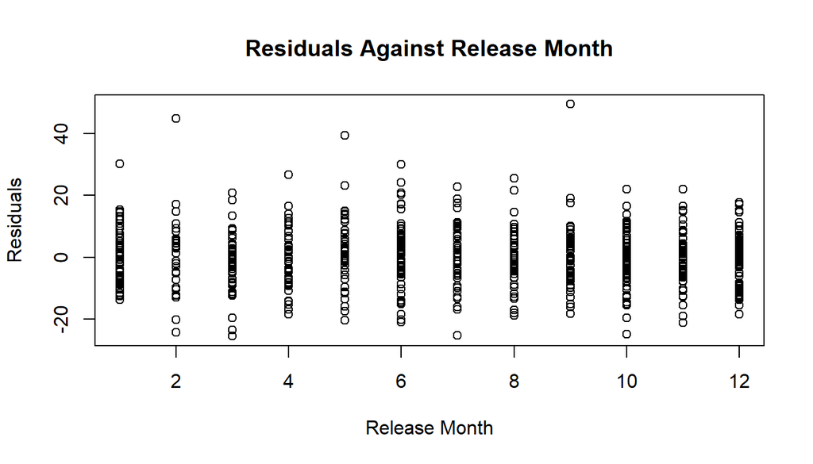

```r
#Residuals against Release Month
plot(final$residuals ~ audience$thtr_rel_month, main = "Residuals Against Release Month",
     ylab = "Residuals", xlab = "Release Month")
```

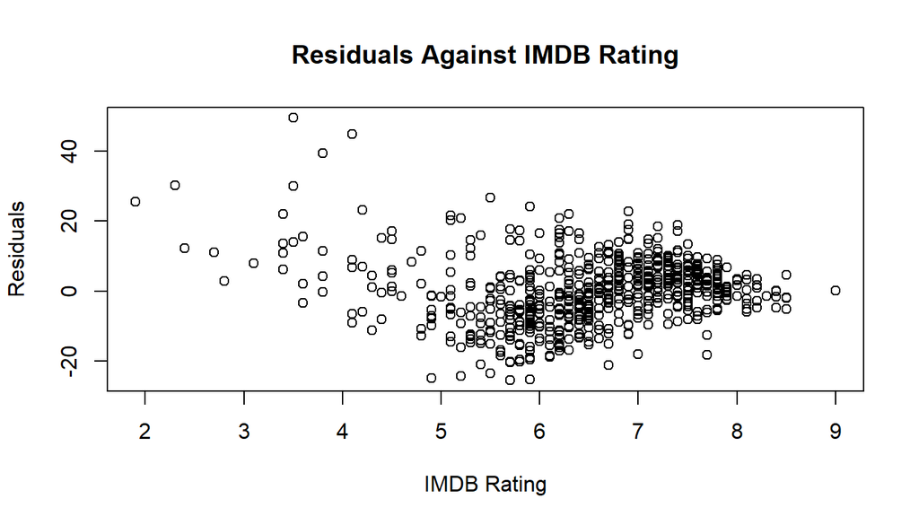

```r
#Residuals against IMDB Rating
plot(final$residuals ~ audience$imdb_rating, main = "Residuals Against IMDB Rating",
     ylab = "Residuals", xlab = "IMDB Rating")
```

For runtime and release month, we see random scatter around 0. For theatre release year, some of the movies in the later years have higher residuals. For imdb_rating, we see higher residulas for ratings lower than 4. This could restrict the generalizability of the model in those ranges but in general, this condition is fairly satisfied.

**Nearly Normal Residuals**  
We want to see random scatter of residuals around 0. This can be checked using a histogram of residuals or a normal probability plot of residuals. We’ll do both here.

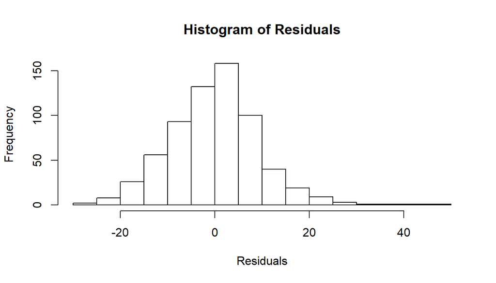

```r
#Histogram of Residuals
hist(final$residuals, main = "Histogram of Residuals", xlab = "Residuals")
```

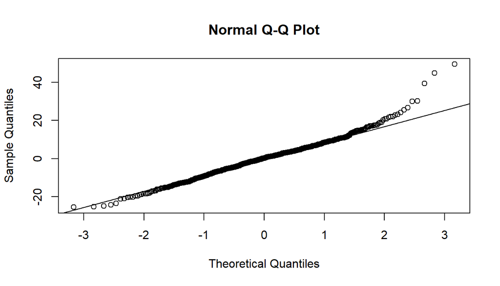

```r
#Normal Probability Plot of Residuals
qqnorm(final$residuals)
qqline(final$residuals)
```

Even though the histogram shows a slight skew, it is nearly normal. The QQ plot is a fairly straight line except for the end values. Hence this condition is satisfied.

**Constant variability of residuals**  
We can check for constant variability of residuals by plotting residuals vs the predicted response values.

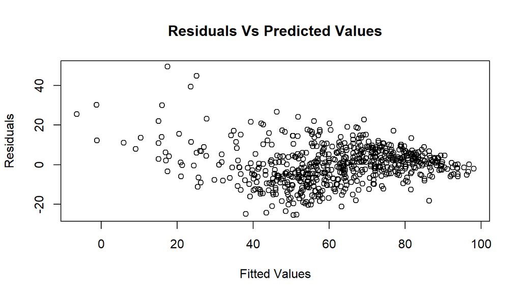

```r
#Residuals Vs Fitted
plot(final$residuals ~ final$fitted, main = "Residuals Vs Predicted Values",
     xlab = "Fitted Values", ylab = "Residuals")
```

**Independence of residuals**  
We can check to see if there is any time series structure embedded in the dataset by plotting residuals against theatre release year.

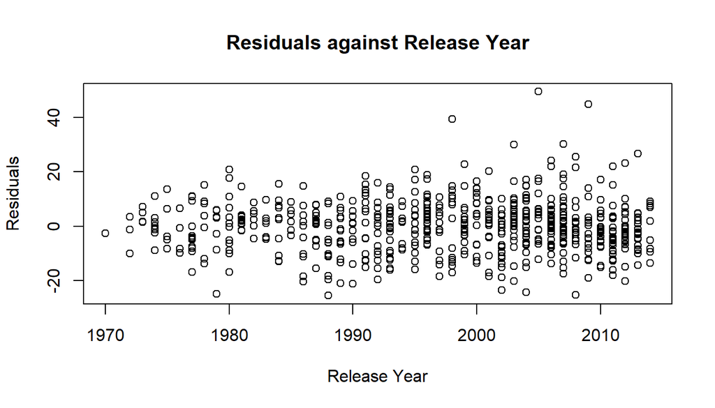

```r
#Residuals against Release Year
plot(final$residuals ~ audience$thtr_rel_year, xlab = "Release Year",
     ylab ="Residuals", main = "Residuals against Release Year")
```

The scatter seems completely random except for a couple of outliers. Hence, from this plot and the random sampling used, we can see that this condition is also satisfied.

## Part 5: Prediction

We are now ready to predict the audience score for a movie that is not included in our dataset. The movie to be predicted is “The Little Prince”, released in August 2016. We have extracted the runtime, release year and month, IMDB rating and critics rating from [Rotten Tomatoes](https://www.rottentomatoes.com/m/the_little_prince_2016) and [IMDB](https://www.imdb.com/title/tt1754656/?ref_=nv_sr_1?ref_=nv_sr_1). We’ll now predict a 95% prediction interval with our model. This means that if repeated samples were taken, then 95% of the samples that contain the true parameter would be between our 95% prediction interval.

```r
predict_movie <- data.frame(genre="Drama",runtime=106, thtr_rel_year = 2016,
                            thtr_rel_month = 8, imdb_rating = 7.7,
                            critics_rating= "Certified Fresh",
                            best_pic_nom = "no", best_actress_win = "no")
predict(final, predict_movie, interval = "predict")
```

```
##        fit      lwr      upr
## 1 82.30032 63.15576 101.4449
```

## Part 6: Conclusion

We have now built a multiple linear regression model that predicts the audience scores on Rotten Tomatoes using a few factors namely, the genre, runtime, release year and month, ratings on IMDB, critics ratings, whether it was nominated for Oscar for best picture and whether it has an actress who won an Oscar before. It is seen that not all of these factors are intrinsic to the movie but some are extrinsic as well. This is a limitation because we won’t be able to predict the audience scores with this model before the movie comes out since we won’t know IMDB ratings, critics ratings and whether it will be nominated for Oscar until after the movie is released. So although it’s pretty accurate, it might not be as accurate if the extrinsic variables were dropped from the model. Another limitation is that the predictions only represent the audience scores on Rotten Tomatoes and may not exactly reflect the actual population’s opinion.